[figure not shown]

# The Hello World Labs

- Hello World 1-1
- Hello World 1-2
- Hello World 1-3
- Hello World 1-4 Advanced!

**Tip:** I used RepL.it as the integrated development environment for these labs. These labs will work with any IDE.

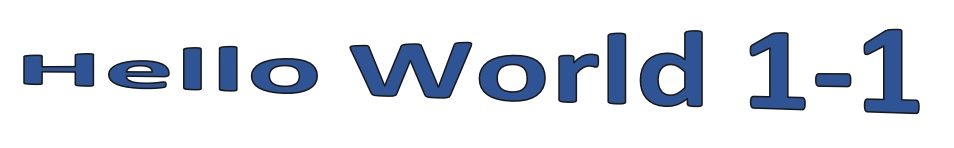

# 1-1 Hello World

This lab is an opportunity to get familiar with your development environment and basic Python statements. You are asked to include basic documentation information in your program and use multiple print statements to display text to the console window.

- Before you start:

  ```
   - Create a new repl.
      - Change repl name to: yourLastNameHello1-1
   - SHARE your repl with instructor!
   - Read the Read.Me file before doing anything!
   - Complete all steps.
  ```

- Read.Me file
- Solution

Top

## 1-1 Read.Me file

```python
#########################################################
##################   Hello World 1-1   ##################
##################                     ##################
#########################################################
#                                                       #
# Before you start:                                     #
#       - Create a new repl.                            #
#       - Change repl name to: yourLastNameHello1-1     #
#       - SHARE your repl with instructor!              #
#       - Read the Read.Me file before doing anything!  #
#       - Complete all steps.                           #
#                                                       #
#  --------------------------------------------------   #
# Steps:                                                #
#        1. Enter Documentation Comments                #
#             a. Name                                   #
#             b. Date                                   #
#             c. Description                            #
#        2. Create a Welcome message                    #
#             a. 2x print() statements                  #
#             b. Friendly message                       #
#                                                       #
#  --------------------------------------------------   #
# Notes:                                                #
#          Errors are expected. Start slow. Fix one     #
#             Error at a time.                          #
#                                                       #
#  --------------------------------------------------   #
# Python Content:                                       #
#          Comments                                     #
#          print() function                             #
#          Strings                                      #
#          Arguments                                    #
#          New Line Escape Character '\n'               #
#                                                       #
#  --------------------------------------------------   #
# Point Values:                                         #
#        Comments:                                      #
#                   Name                      5         #
#                   Date                      5         #
#                   Description               5         #
#                                                       #
#        Welcome Message: (Minimum Requirements)        #
#                   2 print() function        10        #
#                   1 welcome message         5         #
#                                                       #
#                                                       #
#                                            30 Total   #
#                                                       #
#                                                       #
#  --------------------------------------------------   #
#  Rubric:                                              #
#                                                       #
#      Comments:                                        #
#               0-4           5-9           10-15       #
#          ------------   ------------   ------------   #
#               No         Some           Lots of       #
#            Comments       Comments       comments     #
#                          Little         Lots of       #
#                            Detail        details      #
#                                                       #
#      Welcome Message:                                 #
#              0-4           5-9            10-15       #
#         ------------   ------------   ------------    #
#          No print()    Only one       2 or more       #
#           functions     print()        print()        #
#            and/or       function       functions      #
#          No message     AND/OR        Nicely          #
#                        Very short      formatted      #
#                         message        messages       #
#                                                       #
#                                                       #
#########################################################
```

1-1 Top

## 1-1 Hello World Solution

```python
###################################
#   Setps:                        #
# 1a-c. Documentation Comnents.   #
#                                 #
###################################
#  Ernie Drumm, 9/1/2020
#  Description: Hello World!


###############################
#                             #
# 2a. 2x print() statements   #
#                             #
###############################
print("Hello World")

print("\nWelcome to my app!")  # 2b. Friendly message
```

1-1 Top

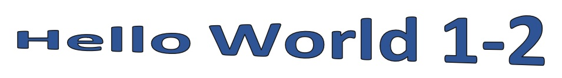

# 1-2 Hello World w/User Input

In this lab assignment you are being asked to collect data from the user and display the data in an easy to read format. Set up the app by providing documentation information (i.e., comments! :). Next welcome the user to the app and give them basic instructions. After the welcome message and instructions is displayed in the console, use the input() function to ask the user to provide four pieces of data (Name, Title, Age, Number). Lastly, in a couple print() statements to nicely format the data the user provided.

- Before you start
  - Fork RepL yourLastNameHello1-1
  - Verify name is chaned to: yourLastNameHello1-2
  - Verify your repl is shared with instructor
  - Read the Read.Me file before doing anything!
  - Complete all steps.
- Read.Me file
- Welcome Messages
- User Input
- Display Data
- Solution

Top

## 1-2 Read.Me file

```python
#########################################################
##################   Hello World 1-2   ##################
##################     User Input      ##################
#########################################################
#
# Before you start:
#       - Fork RepL yourLastNameHello1-1
#       - Verify Repl name: yourLastNameHello1-2
#       - SHARE your repl with instructor!
#       - Read the Read.Me file before doing anything!
#       - Complete all steps.
#
#  --------------------------------------------------
# Steps:
#        1. Update Documentation Comments
#             a. Date
#             b. Description to include User Input
#        2. Welcome message & Instructions
#             a. print() statement to welcome user
#             b. print() statement for instructions
#        3. Add User Input questions
#             a. User Name
#             b. User Title
#             c. User Age
#             d. User Number
#        4. Display data
#             a. Display all user input
#
#  --------------------------------------------------
# Notes:
#          Errors are still expected.
#          Read the error messages!
#
#  --------------------------------------------------
# Python Content Covered:
#          Comments (inline & multi-line)
#          print() function
#          Strings
#          Arguments
#          New Line Escape Character '\n'
#
# NEW Python Content Covered:
#          User Input
#
#
#  --------------------------------------------------
# Point Values:
#        Comments:
#             Name, Date, Description               5
#
#        Welcome Message: (Min Requirements)
#             Welcome Message                       3
#             Instruction Message                   2
#
#        User Input (Ask Questions)
#             Create four (4) variables             5
#             Use input() functions for user input  5
#
#        Display Results: (Min Requirements)
#             Display variable data (4x5pts each)  20
#             Friendly Formatted results            5
#
#                                            45 Total
#
#        BONUS: Casting example                     5
#
#  --------------------------------------------------
#  Rubric:
#
#      Update Comments
#               0-1           2-3          4-5
#          ------------   ------------   ------------
#               No         Some           Lots of
#            Comments       Comments       comments
#               No         Little         Lots of
#             Updates        Detail        details
#                                         Updated
#
#      Welcome Message:
#              0-1           2-3            4-5
#         ------------   ------------   ------------
#          No print()    Only one       2 or more
#           functions     print()        print()
#            and/or       function       functions
#          No message     AND/OR        Nicely
#                        Very short      formatted
#                         message        messages
#
#      input() functions:
#              0-3           4-7           8-10
#         ------------   ------------   ------------
#          No Variables  Missing more    All Variables
#           OR            than one        created
#          Mislabeled     variables      Correct Data
#           Variable     OR               Types
#           Names        Missing data
#           AND/OR       Wrong data      Pleasent
#          Wrong Data     type             questions
#           type         OR              4 input()
#           AND/OR       Missing some      statements
#          No input()     input()
#           statements    statements
#          No question   Incorrect or
#           in input()    missing
#           statements    questions
#
#      Display Results
#              0-10         11-20          21-30
#         ------------   ------------   ------------
#          No print()    Missing 1 or   2 or more print()
#           functions     more print()   functions.
#          Missing        functions.    All variable
#           most of      AND/OR          data printed.
#           the variable Missing 1 or   Proper use of
#           data          more variable  casting.
#          AND/OR         data.         Frendly
#          Very short    Hard to read    formatted
#           message.      formatting
#
#
##########################################################
```

1-2 Top

## 1-2. Welcome Messages and Instructions

Using the print() statements we need to welcome the user to the app and give them some basic instructions.

```python
#2a. Welcome Message
print("Hello and welcome to my app!")

#2b. Instruction message
print("\nBefore we start there are several questions to answer.")
print("\nTo start please enter your Name, Title, Age, and Number\n")
```

1-2 Top

## 1-2. User Input

Using the input() function, ask the user to enter information in the console. Before using the input() function assign the results to a variable.

Below, line 1 is assigning the value of the input() function to the new variable 'uName'. So, the name the user enters will be saved in the newly created variable 'uName'. We can reference the 'uName' variable any time we want access the users name.

```python
uName = input("What is your first name? ")
uTitle = input("What is your Title? ")
uAge = input("What is your Age? ")
uNumber = input("Pick a number you will remember: ")
```

**Be Aware:** We are only collecting data from the user, nothing is being displayed yet. See next section on how to turn all the data into information!

1-2 Top

## 1-2. Display Data

We have the data, now we can use the print() function and escape characters ('\n' for a new line, and '\b' for a back space) to turn the data into some meaninful information.

```python
#4a. Display all user data
print("\n" * 4)  # four blank lines.
print("Welcome to my app", uTitle, uName, "\n")
print(uName, "\b, you said your are", uAge, "years old!\n")
print("Lastly,", uName, "your number is", uNumber, "\n")
```

```
Welcome to my app Warrior Dave

Dave , you said your are 23 years old!

Lastly, Dave your number is 12314
```

1-2 Top

## 1-2 Solution

```python
#1a-b. Update Documentation Comments
#  Ernie Drumm, 9/2/2020
#  Description: Hello World 1-2
#                 with User Input

#2a. Welcome Message
print("Hello and welcome to my app!")

#2b. Instruction message
print("\nBefore we start there are several questions to answer.")
print("\nTo start please enter your Name, Title, Age, and Number\n")

#3a-d. User Input for Name, title, Age, and Number
uName = input("What is your name? >")
uTitle = input("\nWhat is your Title? >")
uAge = input("\nWhat is your Age? >")
uNumber = input("\nPick a number to remember: >")

#4a. Display all user data
print("\n" * 4)
print("Welcome to my app", uTitle, uName, "\n")
print(uName, "\b, you said your are", uAge, "years old!\n")
print("Lastly,", uName, "your number is", uNumber, "\n")
```

```
Hello and welcome to my app!

Before we start there are several questions to answer.

To start please enter your Name, Title, Age, and Number

What is your name? >Mike

What is your Title? >Captain

What is your Age? >34

Pick a number to remember: >75621





Welcome to my app Captain Mike

Mike, you said your are 34 years old!

Lastly, Mike your number is 75621
```

**Tip:** You are encouraged to experiment. Ask different questions and/or print different results.

1-2 Top

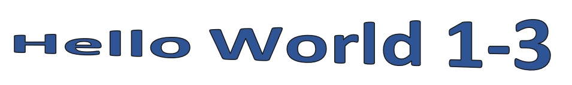

# Hello World 1-3 w/Functions

Functions are used to group statements together. These groups of statements can be called to run whenever we want. Functions help programmers groups code together to organize and streamline the flow code execution. This lab asks you to create three functions. One for each time the app prints to the console window. The app prints three times to the console window with the 'Welcome' message, 'Instructions' message, and lastly the 'Results' message. The goal of this lab is to streamline the app by creating three functions and call those functions. Calling three functions leaves only seven lines of code (1-3 Solution: lines 32-42). Everything else is a comment or function.

- Before you start
  - Fork RepL yourLastNameHello1-2
  - Verify name is chaned to: yourLastNameHello1-3
  - Verify your repl is shared with instructor
  - Read the Read.Me file before doing anything!
  - Complete all steps.
- Read.Me file
- Creating pWelcome function
- Creating pInstructions function
- Creating pResults function
- Calling Functions
- Solution

Top

## 1-3. Read.Me file

```python
#########################################################
##################   Hello World 1-3   ##################
##################      Functions      ##################
#########################################################
#
# Before you start:
#       - Fork RepL yourLastNameHello1-2
#       - Verify Repl name: yourLastNameHello1-3
#       - SHARE your repl with instructor!
#       - Read the Read.Me file before doing anything!
#       - Complete all steps.
#
#  --------------------------------------------------
# Steps:
#        1. Update Documentation Comments
#             a. Date
#             b. Description to include Functions
#        2. Create functions
#             a. pWelcome() function
#             b. pInstructions() function
#             c. pResults() function
#        3. Call functions
#             a. Call pWelcome function
#             b. Call pInstructions() function
#             c. Call pResults function
#
#  --------------------------------------------------
# Notes:
#          Errors have to happen!
#          Read the error messages.
#          Some errors are on the line ABOVE the number given.
#
#  --------------------------------------------------
# Python Content Covered:
#          Comments (inline & multi-line)
#          print() function
#          Strings
#          Arguments
#          New Line Escape Character '\n'
#          User Input
#
# NEW Python Content Covered:
#          Backspace Escape Character '\b'
#          Creating functions
#          Function indentions
#          Calling Functions
#
#  --------------------------------------------------
# Point Values:
#        Update Comments:                           5
#             Name, Date, Description
#
#        Welcome Message: (Min Requirements)        5
#             Welcome Message
#             Instruction Message
#
#        User Input (Ask 4 Questions)               5
#             Create four (4) variables
#             Use input() functions for user input
#
#        Display Results: (Min Requirements)        5
#             Display variable data (4x5pts each)
#             Friendly Formatted results
#
#        Create and Call functions:
#             pWelcome                             10
#             pInstructions                        10
#             pResults                             10
#
#                                                  50 Total
#
#        BONUS: Casting example                     5
#
#  --------------------------------------------------
#  Rubric:
#
#      Update Comments
#               0-1           2-3          4-5
#          ------------   ------------   ------------
#               No         Some           Lots of
#            Comments       Comments       comments
#               No         Little         Lots of
#             Updates        Detail        details
#                                         Updated
#
#      Welcome Message:
#              0-1           2-3            4-5
#         ------------   ------------   ------------
#          No print()    Only one       2 or more
#           functions     print()        print()
#            and/or       function       functions
#          No message     AND/OR        Nicely
#                        Very short      formatted
#                         message        messages
#
#      input() functions:
#              0-1           2-3            4-5
#         ------------   ------------   ------------
#          No Variables  Missing more    All Variables
#           OR            than one        created
#          Mislabeled     variables      Correct Data
#           Variable     OR               Types
#           Names        Missing data
#           AND/OR       Wrong data      Pleasent
#          Wrong Data     type             questions
#           type         OR              4 input()
#           AND/OR       Missing some      statements
#          No input()     input()
#           statements    statements
#          No question   Incorrect or
#           in input()    missing
#           statements    questions
#
#      Display Results
#              0-1           2-3            4-5
#         ------------   ------------   ------------
#          No print()    Missing 1 or   2 or more print()
#           functions     more print()   functions
#          Missing        functions.    All variable
#           most of      AND/OR          data printed.
#           the variable Missing 1 or   Proper use of
#           data          more variable  casting.
#          AND/OR         data.         Frendly
#          Very short    Hard to read    formatted
#           message.      formatting
#
#      Create and Call Functions three functions
#              0-9          10-19           20-30
#         ------------   ------------   ------------
#         No functions   Missing one    All 3 functions
#         AND/OR          function       works correctly
#         Not working    AND/OR         Message text included
#          correctly     Not fully       in function
#          at ALL!        working       Formatted nicely
#                        OR             Friendly messages
#                        Text incorrect
#
##########################################################
```

1-3 Top

## 1-3.2a Create the pWelcome() Function

A function is a group of statements. Even though the Welcome message is only one print() statement, it is enough for a function to work properly.

Below is an example for creating a function. Start with the 'def' keyword followed by the name of the function. I like to give my function names an easy name to remember. For example, since these functions are for printing I like to start them with the letter ‘p’. Lastly, end the function declaration statement with parentheses. That is it for now, later we will look at adding arguments to functions.

```python
def pWelcome():    #2a. Welcome Message Function
    print("Hello and welcome to my app!")
```

1-3 Top

## 1-3.2b Create the pInstructions Function

When this code is run, nothing happens. A function sits and waits to act until it is called on. A function can only execute the statements within the function when it is called.

```python
def pInstructions():  #2b. Instruction message Function
    print("\nBefore we start there are several questions to answer.")
    print("\nTo start please enter your Name, Title, Age, and Number\n")
```

1-3 Top

## 1-3.2c Create the pResults Function

```python
def pResults(): #4a. Display Results Function
    print("\n" * 4)
    print("Welcome to my app", uTitle, uName, "\n")
    print(uName, "\b, you said your are", uAge, "years old!\n")
    print("Lastly,", uName, "your number is", uNumber, "\n")
```

1-3 Top

## 1-3.3a Calling Functions pWelcome & pInstructions

In order to run/execute the statements within a function it needs to be called in the main part of the file. You only need to use the function name to call the function. Below shows the necessary code in order to call the pWelcome function and pInstructions function.

```python
pWelcome()

pInstructions()
```

```
Hello and welcome to my app!

Before we start there are several questions to answer.

To start please enter your Name, Title, Age, and Number
```

1-3 Top

## 1-3 Solution

```python
#1a-b. Update Documentation Comments
#  Ernie Drumm, 9/3/2020
#  Description: Hello World 1-3
#                 with User Input
#                 and Functions

###########################################
#                                         #
# Functions: pWelcome(), pInstructions(), #
#    and pResults()                       #
#                                         #
###########################################
def pWelcome():    #2a. Welcome Message Function
  print("Hello and welcome to my app!")

def pInstructions():  #2b. Instruction message Function
  print("\nBefore we start there are several questions to answer.")
  print("\nTo start please enter your Name, Title, Age, and Number\n")

def pResults(): #3c. Display Results Function
  print("\n" * 4)
  print("Welcome to my app", uTitle, uName, "\n")
  print(uName, "\b, you said your are", uAge, "years old!\n")
  print("Lastly,", uName, "your number is", uNumber, "\n")


########################
#                      #
#   App starts here!   #
#                      #
########################
pWelcome()   #3a. Call pWelcome function

pInstructions()   #3b. Call pInstructions function

# User Input for Name, title, Age, and Number
uName = input("What is your name? >")
uTitle = input("\nWhat is your Title? >")
uAge = input("\nWhat is your Age? >")
uNumber = input("\nPick a number to remember: >")

pResults()   #3c. Call pResults function
```

1-3 Top

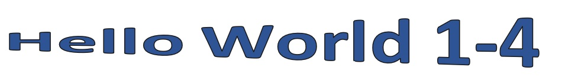

# 1-4 Hello World w/External Functions

- Before you start
  - Fork RepL yourLastNameHello1-3
  - Verify name is chaned to: yourLastNameHello1-4
  - Verify your repl is shared with instructor
  - Read the Read.Me file before doing anything!
- Read.Me file

Top

# Read.Me file

```python
# NOT REQUIRED, advanced lab!  Extra credit applies!

#########################################################
##################   Hello World 1-4   ##################
##################  External Functions ##################
#########################################################
#
# Before you start:
#       - Fork RepL yourLastNameHello1-3
#       - Verify Repl name: yourLastNameHello1-4
#       - SHARE your repl with instructor!
#       - Read the Read.Me file before doing anything!
#       - Complete all steps.
#
#  --------------------------------------------------
# Steps:
#        1. Update Documentation Comments
#             a. Date
#             b. Description to include Functions
#        2. Create prints.py file
#        3. Move all functions to prints.py file
#        4. Import function reference in main.py
```

1-4 Top

### The top of the main.py file

```python
from prints import pWelcome, pInstructions, pResults       #4 import function references
```

1-4 Top